# Kwak_AHP

Cheon Geun Choi

2023-11-02

```r
rm(list=ls())
gc()
```

```
##          used (Mb) gc trigger (Mb) max used (Mb)
## Ncells 505927 27.1    1123384   60   644242 34.5
## Vcells 894114  6.9    8388608   64  1636217 12.5
```

```r
# install.packages("ahpsurvey",repos = "http://cran.us.r-project.org")
library(ahpsurvey)
```

# 1. 데이터 전처리

## 1.1. 데이터 불러오기

```r
library(dplyr)
df1 <- readxl::read_excel("k1.xlsx")
df2 <- readxl::read_excel("k2.xlsx")
df3 <- readxl::read_excel("k3.xlsx")
df4 <- readxl::read_excel("k4.xlsx")
df_cat <- readxl::read_excel("df_cat.xlsx")

head(df1)
```

| inter_inner | inter_actor | inner_actor |
| --- | --- | --- |
| 5 | 3 | -3 |
| -7 | 7 | 7 |
| 4 | 7 | 9 |
| 1 | 5 | 3 |
| -7 | -3 | 3 |
| 5 | 6 | 7 |

```r
head(df2)
```

| inter_foreign | inter_together | inter_safety | foreign_together | foreign_safety | together_safety |
| --- | --- | --- | --- | --- | --- |
| -3 | 2 | 6 | 3 | 7 | 5 |
| -7 | 7 | -7 | 7 | 7 | 7 |
| -6 | 3 | 1 | 6 | 6 | -3 |
| 1 | 4 | 5 | 1 | 5 | 5 |
| 3 | 5 | 3 | 2 | 3 | 2 |
| -4 | 6 | -6 | 6 | -4 | -7 |

```r
head(df3)
```

| capacity_korean | capacity_economic | capacity_strategy | capacity_location | korean_economic | korean_strategy | korean_location | economic_strategy | economic_location | strategy_location |
| --- | --- | --- | --- | --- | --- | --- | --- | --- | --- |
| 8 | 3 | 5 | 7 | -5 | -7 | -3 | -3 | 3 | 7 |
| 7 | 7 | 1 | 5 | -5 | 5 | 5 | -5 | -5 | 5 |
| 4 | -4 | 3 | -3 | -5 | 3 | 2 | 2 | 2 | 1 |
| 3 | 2 | 2 | 2 | -5 | -4 | -3 | 1 | 3 | 3 |
| 3 | 1 | 2 | -2 | 1 | -2 | -4 | -3 | -2 | -2 |
| 5 | 5 | 6 | 6 | 5 | -3 | -5 | -6 | -6 | -5 |

```r
head(df4)
```

| president_officer | president_assembly | president_media | officer_assembly | officer_media | assembly_media |
| --- | --- | --- | --- | --- | --- |
| -5 | -3 | -7 | 3 | -3 | -5 |
| -8 | 5 | -5 | 5 | 5 | 5 |
| -9 | -6 | -6 | 3 | 2 | 1 |
| -6 | 1 | -2 | 5 | -2 | -4 |
| -6 | 1 | 3 | 5 | 3 | -2 |
| -6 | -5 | -2 | -3 | 6 | -6 |

```r
atts1 <- c("inter", "inner", "actor")
atts2 <- c("inter", "foreign", "together", "safety")
atts3 <- c("capacity", "korean", "economic", "strategy", "location")
atts4 <- c("president", "officer", "assembly", "media")
df1ahp <- df1 %>%
  ahp.mat(atts = atts1, negconvert = TRUE)
df2ahp <- df2 %>%
  ahp.mat(atts = atts2, negconvert = TRUE)
df3ahp <- df3 %>%
  ahp.mat(atts = atts3, negconvert = TRUE)
df4ahp <- df4 %>%
  ahp.mat(atts = atts4, negconvert = TRUE)
```

# 2. [설문 Ⅰ-1] “파병정책 결정 요인의 평가영역 사이의 중요성” 비교

## 2.1. CR<0.1이하 제거

```r
cr <- df1 %>%
  ahp.mat(atts1, negconvert = T) %>%
  ahp.cr(atts1)
table(cr <= 0.1)
```

```
##
## FALSE  TRUE
##    17     8
```

0.1 이하

```r
thres<-0.1
cr.df1 <- df1 %>%
  ahp.mat(atts1, negconvert = TRUE) %>%
  ahp.cr(atts1) %>%
  data.frame() %>%
  mutate(rowid = 1:25, cr.dum = as.factor(ifelse(cr <= thres, 1, 0)))
cr.df1 %>%
  filter(cr.dum==1)
```

| . | rowid | cr.dum |
| --- | --- | --- |
| 3.666545e-02 | 1 | 1 |
| 2.767089e-02 | 4 | 1 |
| 6.685248e-03 | 5 | 1 |
| -8.456126e-16 | 17 | 1 |
| 0.000000e+00 | 21 | 1 |
| 5.105177e-02 | 22 | 1 |
| 0.000000e+00 | 23 | 1 |
| 6.999040e-02 | 24 | 1 |

```r
cr1.df1   <- df1 %>%
   mutate(rowid = 1:25)

df1n <- inner_join(cr1.df1, cr.df1) %>%
  filter(cr.dum==1)%>%
  select(1:3)
```

## 2.2. 논문초안 79페이지 [표5-1] 상대적 중요도

### 상대적 중요도

```r
mean <- df1n %>%
  ahp.mat(atts = atts1, negconvert = TRUE) %>%
  ahp.aggpref(atts1, method = "arithmetic")
mean
```

```
##     inter     inner     actor
## 0.4253290 0.1729622 0.4017087
```

### 하단 별표 평균 CR = 0.024

```r
cr <- df1n %>%
  ahp.mat(atts1, negconvert = T) %>%
  ahp.cr(atts1)
mean(cr)
```

```
## [1] 0.02400797
```

# 3. [설문 2-1]

## 3.1. CR<0.1이하 제거

```r
cr <- df2 %>%
  ahp.mat(atts2, negconvert = T) %>%
  ahp.cr(atts2)
table(cr <= 0.1)
```

```
##
## FALSE  TRUE
##    13    12
```

0.1 이하

```r
thres<-0.1
cr.df2 <- df2 %>%
  ahp.mat(atts2, negconvert = TRUE) %>%
  ahp.cr(atts2) %>%
  data.frame() %>%
  mutate(rowid = 1:25, cr.dum = as.factor(ifelse(cr <= thres, 1, 0)))
cr.df2 %>%
  filter(cr.dum==1)
```

| . | rowid | cr.dum |
| --- | --- | --- |
| 5.290186e-02 | 1 | 1 |
| 5.828034e-02 | 3 | 1 |
| 9.401214e-02 | 4 | 1 |
| 6.704180e-02 | 5 | 1 |
| 2.771299e-02 | 8 | 1 |
| 2.287708e-02 | 13 | 1 |
| 2.935573e-03 | 15 | 1 |
| 1.402909e-02 | 16 | 1 |
| -3.350358e-16 | 17 | 1 |
| 7.740246e-02 | 18 | 1 |

[output cut: 2 more lines]

```r
cr1.df2   <- df2 %>%
   mutate(rowid = 1:25)

df2n <- inner_join(cr1.df2, cr.df2) %>%
  filter(cr.dum==1)%>%
  select(1:6)
```

## 3.2. 논문초안 80페이지 [표5-2] 상대적 중요도

### 상대적 중요도

```r
mean <- df2n %>%
  ahp.mat(atts = atts2, negconvert = TRUE) %>%
  ahp.aggpref(atts2, method = "arithmetic")
mean
```

```
##     inter   foreign  together    safety
## 0.2373844 0.2220245 0.2424104 0.2981807
```

```r
cr <- df2n %>%
  ahp.mat(atts2, negconvert = T) %>%
  ahp.cr(atts2)
mean(cr)
```

```
## [1] 0.04730747
```

# 4. [설문 2-2]

```r
cr <- df3 %>%
  ahp.mat(atts3, negconvert = T) %>%
  ahp.cr(atts3)
table(cr <= 0.1)
```

```
##
## FALSE  TRUE
##    16     9
```

0.1 이하

```r
thres<-0.1
cr.df3 <- df3 %>%
  ahp.mat(atts3, negconvert = TRUE) %>%
  ahp.cr(atts3) %>%
  data.frame() %>%
  mutate(rowid = 1:25, cr.dum = as.factor(ifelse(cr <= thres, 1, 0)))
cr.df3 %>%
  filter(cr.dum==1)
```

| . | rowid | cr.dum |
| --- | --- | --- |
| 0.058664945 | 4 | 1 |
| 0.066016177 | 5 | 1 |
| 0.053846619 | 7 | 1 |
| 0.002992253 | 8 | 1 |
| 0.068985651 | 13 | 1 |
| 0.071714455 | 14 | 1 |
| 0.000000000 | 17 | 1 |
| 0.061635987 | 24 | 1 |
| 0.053577058 | 25 | 1 |

```r
cr1.df3   <- df3 %>%
   mutate(rowid = 1:25)

df3n <- inner_join(cr1.df3, cr.df3) %>%
  filter(cr.dum==1)%>%
  select(1:10)
```

## 4.2. 논문초안 81페이지 [표5-3] 상대적 중요도

### 상대적 중요도

```r
mean <- df3n %>%
  ahp.mat(atts = atts3, negconvert = TRUE) %>%
  ahp.aggpref(atts3, method = "arithmetic")
mean
```

```
##  capacity    korean  economic  strategy  location
## 0.2350879 0.1973460 0.2112991 0.1899084 0.1663587
```

### 하단 별표 평균

```r
cr <- df3n %>%
  ahp.mat(atts3, negconvert = T) %>%
  ahp.cr(atts3)
mean(cr)
```

```
## [1] 0.04860368
```

# 5. [설문 2-3]

## 5.1. CR<0.1이하 제거

```r
cr <- df4 %>%
  ahp.mat(atts4, negconvert = T) %>%
  ahp.cr(atts4)
table(cr <= 0.1)
```

```
##
## FALSE  TRUE
##    16     9
```

0.1 이하

```r
thres<-0.1
cr.df4 <- df4 %>%
  ahp.mat(atts4, negconvert = TRUE) %>%
  ahp.cr(atts4) %>%
  data.frame() %>%
  mutate(rowid = 1:25, cr.dum = as.factor(ifelse(cr <= thres, 1, 0)))
cr.df4 %>%
  filter(cr.dum==1)
```

| . | rowid | cr.dum |
| --- | --- | --- |
| 0.04412774 | 1 | 1 |
| 0.01728380 | 3 | 1 |
| 0.04256139 | 7 | 1 |
| 0.05024641 | 9 | 1 |
| 0.08919971 | 13 | 1 |
| 0.04576407 | 15 | 1 |
| 0.03142216 | 16 | 1 |
| 0.06219482 | 21 | 1 |
| 0.06857519 | 22 | 1 |

```r
cr1.df4   <- df4 %>%
   mutate(rowid = 1:25)

df4n <- inner_join(cr1.df4, cr.df4) %>%
  filter(cr.dum==1)%>%
  select(1:6)
```

## 5.2. 논문초안 82페이지 [표5-3] 상대적 중요도

### 상대적 중요도

```r
mean <- df4n %>%
  ahp.mat(atts = atts4, negconvert = TRUE) %>%
  ahp.aggpref(atts4, method = "arithmetic")
mean
```

```
## president   officer  assembly     media
## 0.4637191 0.1807063 0.2106244 0.1449501
```

### 하단 별표 평균

```r
cr <- df4n %>%
  ahp.mat(atts4, negconvert = T) %>%
  ahp.cr(atts4)
mean(cr)
```

```
## [1] 0.05015281
```

# 6. 전문가그룹별(공무원1, 교수요원등2)

## 6.1. /[설문 Ⅰ-1] “파병정책 결정 요인의 평가영역 사이의 중요성” 비교

### 6.1.1. CR<0.1이하 제거

```r
df.cat   <- df_cat %>%
   mutate(rowid = 1:25)
df1n.cat <- inner_join(cr1.df1, cr.df1)
df1ncat1 <- inner_join(df1n.cat, df.cat) %>%
  filter(cr.dum==1 & cat==1)%>%
  select(1:3)
df1ncat2 <- inner_join(df1n.cat, df.cat) %>%
  filter(cr.dum==1 & cat==2)%>%
  select(1:3)
```

### 6.1.2. 그룹1 상대적 중요도/CR

```r
mean <- df1ncat1 %>%
  ahp.mat(atts = atts1, negconvert = TRUE) %>%
  ahp.aggpref(atts1, method = "arithmetic")
mean
```

```
##     inter     inner     actor
## 0.5308942 0.1065402 0.3625657
```

```r
cr <- df1ncat1 %>%
  ahp.mat(atts1, negconvert = T) %>%
  ahp.cr(atts1)
mean(cr)
```

```
## [1] 0.02589972
```

### 6.1.3. 그룹2 상대적 중요도/CR

```r
mean <- df1ncat2 %>%
  ahp.mat(atts = atts1, negconvert = TRUE) %>%
  ahp.aggpref(atts1, method = "arithmetic")
mean
```

```
##     inter     inner     actor
## 0.1086337 0.3722284 0.5191379
```

```r
cr <- df1ncat2 %>%
  ahp.mat(atts=atts1, negconvert = TRUE) %>%
  ahp.cr(atts1)
mean(cr)
```

```
## [1] 0.01833273
```

## 6.2. /(설문 2-1)

### 6.2.1. CR<0.1이하 제거

```r
df2n.cat <- inner_join(cr1.df2, cr.df2)
df2ncat1 <- inner_join(df2n.cat, df.cat) %>%
  filter(cr.dum==1 & cat==1)%>%
  select(1:6)
df2ncat2 <- inner_join(df2n.cat, df.cat) %>%
  filter(cr.dum==1 & cat==2)%>%
  select(1:6)
```

### 6.2.2. 그룹1 상대적 중요도/CR

```r
mean <- df2ncat1 %>%
  ahp.mat(atts = atts2, negconvert = TRUE) %>%
  ahp.aggpref(atts2, method = "arithmetic")
mean
```

```
##     inter   foreign  together    safety
## 0.1801833 0.1525073 0.3418430 0.3254664
```

```r
cr <- df2ncat1 %>%
  ahp.mat(atts2, negconvert = T) %>%
  ahp.cr(atts2)
mean(cr)
```

```
## [1] 0.06160621
```

### 6.2.3. 그룹2 상대적 중요도/CR

```r
mean <- df2ncat2 %>%
  ahp.mat(atts = atts2, negconvert = TRUE) %>%
  ahp.aggpref(atts2, method = "arithmetic")
mean
```

```
##     inter   foreign  together    safety
## 0.2782423 0.2716796 0.1713871 0.2786909
```

```r
cr <- df2ncat2 %>%
  ahp.mat(atts=atts2, negconvert = TRUE) %>%
  ahp.cr(atts2)
mean(cr)
```

```
## [1] 0.03709408
```

## 6.3. /(설문 2-2)

### 6.3.1. CR<0.1이하 제거

```r
df3n.cat <- inner_join(cr1.df3, cr.df3)
df3ncat1 <- inner_join(df3n.cat, df.cat) %>%
  filter(cr.dum==1 & cat==1)%>%
  select(1:10)
df3ncat2 <- inner_join(df3n.cat, df.cat) %>%
  filter(cr.dum==1 & cat==2)%>%
  select(1:10)
```

### 6.3.2. 그룹1 상대적 중요도/CR

```r
mean <- df3ncat1 %>%
  ahp.mat(atts = atts3, negconvert = TRUE) %>%
  ahp.aggpref(atts3, method = "arithmetic")
mean
```

```
##  capacity    korean  economic  strategy  location
## 0.2275933 0.2340223 0.2292604 0.1872384 0.1218856
```

```r
cr <- df3ncat1 %>%
  ahp.mat(atts3, negconvert = T) %>%
  ahp.cr(atts3)
mean(cr)
```

```
## [1] 0.0486312
```

### 6.3.3. 그룹2 상대적 중요도/CR

```r
mean <- df3ncat2 %>%
  ahp.mat(atts = atts3, negconvert = TRUE) %>%
  ahp.aggpref(atts3, method = "arithmetic")
mean
```

```
##  capacity    korean  economic  strategy  location
## 0.2444560 0.1515006 0.1888475 0.1932459 0.2219500
```

```r
cr <- df3ncat2 %>%
  ahp.mat(atts=atts3, negconvert = TRUE) %>%
  ahp.cr(atts3)
mean(cr)
```

```
## [1] 0.04856929
```

## 6.4. /(설문 2-3)

### 6.4.1. CR<0.1이하 제거

```r
df4n.cat <- inner_join(cr1.df4, cr.df4)
df4ncat1 <- inner_join(df4n.cat, df.cat) %>%
  filter(cr.dum==1 & cat==1)%>%
  select(1:6)
df4ncat2 <- inner_join(df4n.cat, df.cat) %>%
  filter(cr.dum==1 & cat==2)%>%
  select(1:6)
```

### 6.4.2. 그룹1 상대적 중요도/CR

```r
mean <- df4ncat1 %>%
  ahp.mat(atts = atts4, negconvert = TRUE) %>%
  ahp.aggpref(atts4, method = "arithmetic")
mean
```

```
## president   officer  assembly     media
## 0.4668560 0.1080815 0.2791554 0.1459071
```

```r
cr <- df4ncat1 %>%
  ahp.mat(atts4, negconvert = T) %>%
  ahp.cr(atts4)
mean(cr)
```

```
## [1] 0.04817232
```

### 6.4.3. 그룹2 상대적 중요도/CR

```r
mean <- df4ncat2 %>%
  ahp.mat(atts = atts4, negconvert = TRUE) %>%
  ahp.aggpref(atts4, method = "arithmetic")
mean
```

```
## president   officer  assembly     media
## 0.4597980 0.2714873 0.1249607 0.1437539
```

```r
cr <- df4ncat2 %>%
  ahp.mat(atts=atts4, negconvert = TRUE) %>%
  ahp.cr(atts4)
mean(cr)
```

```
## [1] 0.05262842
```

## 6.5. 상관관계분석(91p)

### 6.5.1. 데이터불러오기

```r
dfwt <- readxl::read_excel("wt.xlsx")

head(dfwt)
```

| v1 | v2 | v3 | v4 |
| --- | --- | --- | --- |
| 0.0940 | 0.0300 | 5 | 10 |
| 0.0805 | 0.0292 | 6 | 12 |
| 0.1807 | 0.0184 | 1 | 13 |
| 0.1722 | 0.0300 | 2 | 10 |
| 0.0240 | 0.0907 | 11 | 3 |
| 0.0248 | 0.0561 | 9 | 9 |

### 6.5.2. 서열상관관계

- Spearman의 rho 통계는 순위 기반 연관성 측정을 추정하는 데 사용됩니다. 이 테스트는 데이터가 이변량 정규 분포에서 나오지 않는 경우에 사용할 수 있습니다.

```r
cor.test(dfwt$v1, dfwt$v2,  method = "spearman")
```

```
##
##  Spearman's rank correlation rho
##
## data:  dfwt$v1 and dfwt$v2
## S = 533.23, p-value = 0.1094
## alternative hypothesis: true rho is not equal to 0
## sample estimates:
##        rho
## -0.4649248
```

- Kendall 순위 상관 계수 또는 Kendall의 타우 통계는 순위 기반 연관성 측정을 추정하는 데 사용됩니다. 이 테스트는 데이터가 반드시 이변량 정규 분포에서 나오지 않는 경우에 사용할 수 있습니다

```r
cor.test(dfwt$v1, dfwt$v2,  method = "kendall")
```

```
##
##  Kendall's rank correlation tau
##
## data:  dfwt$v1 and dfwt$v2
## z = -1.6503, p-value = 0.09888
## alternative hypothesis: true tau is not equal to 0
## sample estimates:
##        tau
## -0.3483943
```

```r
cor.test(dfwt$v1, dfwt$v2,  method ="pearson")
```

```
##
##  Pearson's product-moment correlation
##
## data:  dfwt$v1 and dfwt$v2
## t = 0.098583, df = 11, p-value = 0.9232
## alternative hypothesis: true correlation is not equal to 0
## 95 percent confidence interval:
##  -0.529950  0.571343
## sample estimates:
##       cor
## 0.0297107
```

# 7. 요구분석

```r
dfnd <- readxl::read_excel("dfnd.xlsx")

head(dfnd)
```

| no | q1_1 | q1_2 | q1_3 | q1_4 | q1_5 | q1_6 | q1_7 | q1_8 | q1_9 | q1_10 | q1_11 | q1_12 | q1_13 | q2_1 | q2_2 | q2_3 | q2_4 | q2_5 | q2_6 | q2_7 | q2_8 | q2_9 | q2_10 | q2_11 | q2_12 | q2_13 |
| --- | --- | --- | --- | --- | --- | --- | --- | --- | --- | --- | --- | --- | --- | --- | --- | --- | --- | --- | --- | --- | --- | --- | --- | --- | --- | --- |
| 1 | 5 | 3 | 6 | 8 | 3 | 7 | 5 | 4 | 6 | 8 | 4 | 6 | 2 | 6 | 4 | 6 | 8 | 5 | 7 | 4 | 4 | 6 | 7 | 3 | 6 | 5 |
| 2 | 5 | 6 | 7 | 2 | 1 | 1 | 7 | 2 | 5 | 6 | 3 | 5 | 6 | 7 | 7 | 7 | 2 | 2 | 3 | 7 | 5 | 2 | 7 | 6 | 3 | 3 |
| 3 | 5 | 5 | 7 | 7 | 6 | 7 | 4 | 6 | 6 | 8 | 5 | 7 | 7 | 6 | 5 | 7 | 7 | 7 | 7 | 6 | 7 | 7 | 8 | 6 | 7 | 7 |
| 4 | 5 | 2 | 6 | 7 | 4 | 5 | 2 | 2 | 5 | 7 | 5 | 6 | 4 | 6 | 3 | 6 | 8 | 5 | 5 | 2 | 2 | 5 | 7 | 4 | 6 | 5 |
| 5 | 6 | 6 | 7 | 7 | 6 | 7 | 7 | 6 | 5 | 8 | 7 | 7 | 7 | 7 | 6 | 7 | 8 | 6 | 7 | 8 | 7 | 5 | 8 | 7 | 8 | 7 |
| 6 | 6 | 7 | 8 | 5 | 6 | 7 | 6 | 6 | 5 | 8 | 2 | 2 | 7 | 4 | 7 | 8 | 7 | 7 | 6 | 7 | 5 | 3 | 8 | 2 | 2 | 7 |

## 7.1. [표5-12] 중요도 수준에 대한 t검정

### 7.1.1. 평균

```r
mean(dfnd$q1_1)
```

```
## [1] 6.84
```

```r
mean(dfnd$q1_2)
```

```
## [1] 5.48
```

```r
mean(dfnd$q1_2)
```

```
## [1] 5.48
```

```r
mean(dfnd$q1_3)
```

```
## [1] 6.52
```

```r
mean(dfnd$q1_4)
```

```
## [1] 5.64
```

```r
mean(dfnd$q1_5)
```

```
## [1] 5.4
```

```r
mean(dfnd$q1_6)
```

```
## [1] 5.72
```

```r
mean(dfnd$q1_7)
```

```
## [1] 5.48
```

```r
mean(dfnd$q1_8)
```

```
## [1] 4.96
```

```r
mean(dfnd$q1_9)
```

```
## [1] 4.76
```

```r
mean(dfnd$q1_10)
```

```
## [1] 7.32
```

```r
mean(dfnd$q1_11)
```

```
## [1] 5.36
```

```r
mean(dfnd$q1_12)
```

```
## [1] 6.16
```

```r
mean(dfnd$q1_13)
```

```
## [1] 5.88
```

```r
mean(dfnd$q2_1)
```

```
## [1] 7.6
```

```r
mean(dfnd$q2_2)
```

```
## [1] 6.24
```

```r
mean(dfnd$q2_2)
```

```
## [1] 6.24
```

```r
mean(dfnd$q2_3)
```

```
## [1] 6.96
```

```r
mean(dfnd$q2_4)
```

```
## [1] 6.36
```

```r
mean(dfnd$q2_5)
```

```
## [1] 5.84
```

```r
mean(dfnd$q2_6)
```

```
## [1] 6
```

```r
mean(dfnd$q2_7)
```

```
## [1] 6.6
```

```r
mean(dfnd$q2_8)
```

```
## [1] 6.08
```

```r
mean(dfnd$q2_9)
```

```
## [1] 4.8
```

```r
mean(dfnd$q2_10)
```

```
## [1] 7.48
```

```r
mean(dfnd$q2_11)
```

```
## [1] 5.44
```

```r
mean(dfnd$q2_12)
```

```
## [1] 6.24
```

```r
mean(dfnd$q2_13)
```

```
## [1] 6.8
```

### 7.1.2. 표준편차

```r
sd(dfnd$q1_1)
```

```
## [1] 1.491085
```

```r
sd(dfnd$q1_2)
```

```
## [1] 1.960442
```

```r
sd(dfnd$q1_3)
```

```
## [1] 1.262273
```

```r
sd(dfnd$q1_4)
```

```
## [1] 2.289105
```

```r
sd(dfnd$q1_5)
```

```
## [1] 1.936492
```

```r
sd(dfnd$q1_6)
```

```
## [1] 2.010804
```

```r
sd(dfnd$q1_7)
```

```
## [1] 1.557776
```

```r
sd(dfnd$q1_8)
```

```
## [1] 1.593738
```

```r
sd(dfnd$q1_9)
```

```
## [1] 1.942507
```

```r
sd(dfnd$q1_10)
```

```
## [1] 0.9882645
```

```r
sd(dfnd$q1_11)
```

```
## [1] 1.704895
```

```r
sd(dfnd$q1_12)
```

```
## [1] 1.675311
```

```r
sd(dfnd$q1_13)
```

```
## [1] 1.763519
```

```r
sd(dfnd$q2_1)
```

```
## [1] 1.527525
```

```r
sd(dfnd$q2_2)
```

```
## [1] 1.738774
```

```r
sd(dfnd$q2_3)
```

```
## [1] 1.540563
```

```r
sd(dfnd$q2_4)
```

```
## [1] 2.2151
```

```r
sd(dfnd$q2_5)
```

```
## [1] 1.993322
```

```r
sd(dfnd$q2_6)
```

```
## [1] 1.581139
```

```r
sd(dfnd$q2_7)
```

```
## [1] 2.179449
```

```r
sd(dfnd$q2_8)
```

```
## [1] 1.891208
```

```r
sd(dfnd$q2_9)
```

```
## [1] 2.140872
```

```r
sd(dfnd$q2_10)
```

```
## [1] 1.122497
```

```r
sd(dfnd$q2_11)
```

```
## [1] 2.103172
```

```r
sd(dfnd$q2_12)
```

```
## [1] 1.809236
```

```r
sd(dfnd$q2_13)
```

```
## [1] 1.607275
```

### 7.1.3. 차이 평균/표준편차

```r
dfnd$qd1<-(dfnd$q2_1 - dfnd$q1_1)
dfnd$qd2<-(dfnd$q2_2 - dfnd$q1_2)
dfnd$qd3<-(dfnd$q2_3 - dfnd$q1_3)
dfnd$qd4<-(dfnd$q2_4 - dfnd$q1_4)
dfnd$qd5<-(dfnd$q2_5 - dfnd$q1_5)
dfnd$qd6<-(dfnd$q2_6 - dfnd$q1_6)
dfnd$qd7<-(dfnd$q2_7 - dfnd$q1_7)
dfnd$qd8<-(dfnd$q2_8 - dfnd$q1_8)
dfnd$qd9<-(dfnd$q2_9 - dfnd$q1_9)
dfnd$qd10<-(dfnd$q2_10 - dfnd$q1_10)
dfnd$qd11<-(dfnd$q2_11 - dfnd$q1_11)
dfnd$qd12<-(dfnd$q2_12 - dfnd$q1_12)
dfnd$qd13<-(dfnd$q2_13 - dfnd$q1_13)
```

- 아래는 각 요소별 미래 중요도 - 현재 중요도의 평균(mean)과 표준편차(sd)
- 예컨대, dfnd$qd1 변수는 첫번재 요소의 미래중요도 - 현재 중요도의 값임. 여기에 평균과 표준편차를 계산함

```r
mean(dfnd$qd1)
```

```
## [1] 0.76
```

```r
sd(dfnd$qd1)
```

```
## [1] 1.128421
```

```r
mean(dfnd$qd2)
```

```
## [1] 0.76
```

```r
sd(dfnd$qd2)
```

```
## [1] 1.234234
```

```r
mean(dfnd$qd3)
```

```
## [1] 0.44
```

```r
sd(dfnd$qd3)
```

```
## [1] 0.9165151
```

```r
mean(dfnd$qd4)
```

```
## [1] 0.72
```

```r
sd(dfnd$qd4)
```

```
## [1] 0.8906926
```

```r
mean(dfnd$qd5)
```

```
## [1] 0.44
```

```r
sd(dfnd$qd5)
```

```
## [1] 1.121011
```

```r
mean(dfnd$qd6)
```

```
## [1] 0.28
```

```r
sd(dfnd$qd6)
```

```
## [1] 1.339154
```

```r
mean(dfnd$qd7)
```

```
## [1] 1.12
```

```r
sd(dfnd$qd7)
```

```
## [1] 1.615549
```

```r
mean(dfnd$qd8)
```

```
## [1] 1.12
```

```r
sd(dfnd$qd8)
```

```
## [1] 1.9
```

```r
mean(dfnd$qd9)
```

```
## [1] 0.04
```

```r
sd(dfnd$qd9)
```

```
## [1] 1.619671
```

```r
mean(dfnd$qd10)
```

```
## [1] 0.16
```

```r
sd(dfnd$qd10)
```

```
## [1] 1.106044
```

```r
mean(dfnd$qd11)
```

```
## [1] 0.08
```

```r
sd(dfnd$qd11)
```

```
## [1] 1.28841
```

```r
mean(dfnd$qd12)
```

```
## [1] 0.08
```

```r
sd(dfnd$qd12)
```

```
## [1] 1.115049
```

```r
mean(dfnd$qd13)
```

```
## [1] 0.92
```

```r
sd(dfnd$qd13)
```

```
## [1] 1.800926
```

### 7.1.4. t검증

```r
t.test(dfnd$q1_1, dfnd$q2_1)
```

```
##
##  Welch Two Sample t-test
##
## data:  dfnd$q1_1 and dfnd$q2_1
## t = -1.7802, df = 47.972, p-value = 0.08138
## alternative hypothesis: true difference in means is not equal to 0
## 95 percent confidence interval:
##  -1.6184072  0.0984072
## sample estimates:
## mean of x mean of y
##      6.84      7.60
```

```r
t.test(dfnd$q1_2, dfnd$q2_2)
```

```
##
##  Welch Two Sample t-test
##
## data:  dfnd$q1_2 and dfnd$q2_2
## t = -1.4501, df = 47.325, p-value = 0.1536
## alternative hypothesis: true difference in means is not equal to 0
## 95 percent confidence interval:
##  -1.8141349  0.2941349
## sample estimates:
## mean of x mean of y
##      5.48      6.24
```

```r
t.test(dfnd$q1_3, dfnd$q2_3)
```

```
##
##  Welch Two Sample t-test
##
## data:  dfnd$q1_3 and dfnd$q2_3
## t = -1.1046, df = 46.213, p-value = 0.275
## alternative hypothesis: true difference in means is not equal to 0
## 95 percent confidence interval:
##  -1.2416966  0.3616966
## sample estimates:
## mean of x mean of y
##      6.52      6.96
```

```r
t.test(dfnd$q1_4, dfnd$q2_4)
```

```
##
##  Welch Two Sample t-test
##
## data:  dfnd$q1_4 and dfnd$q2_4
## t = -1.1302, df = 47.948, p-value = 0.264
## alternative hypothesis: true difference in means is not equal to 0
## 95 percent confidence interval:
##  -2.0009642  0.5609642
## sample estimates:
## mean of x mean of y
##      5.64      6.36
```

```r
t.test(dfnd$q1_5, dfnd$q2_5)
```

```
##
##  Welch Two Sample t-test
##
## data:  dfnd$q1_5 and dfnd$q2_5
## t = -0.79163, df = 47.96, p-value = 0.4325
## alternative hypothesis: true difference in means is not equal to 0
## 95 percent confidence interval:
##  -1.5575706  0.6775706
## sample estimates:
## mean of x mean of y
##      5.40      5.84
```

```r
t.test(dfnd$q1_6, dfnd$q2_6)
```

```
##
##  Welch Two Sample t-test
##
## data:  dfnd$q1_6 and dfnd$q2_6
## t = -0.5473, df = 45.47, p-value = 0.5868
## alternative hypothesis: true difference in means is not equal to 0
## 95 percent confidence interval:
##  -1.3101187  0.7501187
## sample estimates:
## mean of x mean of y
##      5.72      6.00
```

```r
t.test(dfnd$q1_7, dfnd$q2_7)
```

```
##
##  Welch Two Sample t-test
##
## data:  dfnd$q1_7 and dfnd$q2_7
## t = -2.0904, df = 43.447, p-value = 0.04247
## alternative hypothesis: true difference in means is not equal to 0
## 95 percent confidence interval:
##  -2.20019438 -0.03980562
## sample estimates:
## mean of x mean of y
##      5.48      6.60
```

```r
t.test(dfnd$q1_8, dfnd$q2_8)
```

```
##
##  Welch Two Sample t-test
##
## data:  dfnd$q1_8 and dfnd$q2_8
## t = -2.2643, df = 46.66, p-value = 0.02825
## alternative hypothesis: true difference in means is not equal to 0
## 95 percent confidence interval:
##  -2.1152747 -0.1247253
## sample estimates:
## mean of x mean of y
##      4.96      6.08
```

```r
t.test(dfnd$q1_9, dfnd$q2_9)
```

```
##
##  Welch Two Sample t-test
##
## data:  dfnd$q1_9 and dfnd$q2_9
## t = -0.069185, df = 47.553, p-value = 0.9451
## alternative hypothesis: true difference in means is not equal to 0
## 95 percent confidence interval:
##  -1.202747  1.122747
## sample estimates:
## mean of x mean of y
##      4.76      4.80
```

```r
t.test(dfnd$q1_10, dfnd$q2_10)
```

```
##
##  Welch Two Sample t-test
##
## data:  dfnd$q1_10 and dfnd$q2_10
## t = -0.53492, df = 47.242, p-value = 0.5952
## alternative hypothesis: true difference in means is not equal to 0
## 95 percent confidence interval:
##  -0.76165  0.44165
## sample estimates:
## mean of x mean of y
##      7.32      7.48
```

```r
t.test(dfnd$q1_11, dfnd$q2_11)
```

```
##
##  Welch Two Sample t-test
##
## data:  dfnd$q1_11 and dfnd$q2_11
## t = -0.14774, df = 46.029, p-value = 0.8832
## alternative hypothesis: true difference in means is not equal to 0
## 95 percent confidence interval:
##  -1.169923  1.009923
## sample estimates:
## mean of x mean of y
##      5.36      5.44
```

```r
t.test(dfnd$q1_12, dfnd$q2_12)
```

```
##
##  Welch Two Sample t-test
##
## data:  dfnd$q1_12 and dfnd$q2_12
## t = -0.16222, df = 47.719, p-value = 0.8718
## alternative hypothesis: true difference in means is not equal to 0
## 95 percent confidence interval:
##  -1.0717017  0.9117017
## sample estimates:
## mean of x mean of y
##      6.16      6.24
```

```r
t.test(dfnd$q1_13, dfnd$q2_13)
```

```
##
##  Welch Two Sample t-test
##
## data:  dfnd$q1_13 and dfnd$q2_13
## t = -1.9279, df = 47.593, p-value = 0.05985
## alternative hypothesis: true difference in means is not equal to 0
## 95 percent confidence interval:
##  -1.8797155  0.0397155
## sample estimates:
## mean of x mean of y
##      5.88      6.80
```

### 7.1.4. 보리치 요구도

```r
mean((dfnd$q2_1 - dfnd$q1_1)*mean(dfnd$q2_1))
```

```
## [1] 5.776
```

```r
mean((dfnd$q2_2 - dfnd$q1_2)*mean(dfnd$q2_2))
```

```
## [1] 4.7424
```

```r
mean((dfnd$q2_3 - dfnd$q1_3)*mean(dfnd$q2_3))
```

```
## [1] 3.0624
```

```r
mean((dfnd$q2_4 - dfnd$q1_4)*mean(dfnd$q2_4))
```

```
## [1] 4.5792
```

```r
mean((dfnd$q2_5 - dfnd$q1_5)*mean(dfnd$q2_5))
```

```
## [1] 2.5696
```

```r
mean((dfnd$q2_6 - dfnd$q1_6)*mean(dfnd$q2_6))
```

```
## [1] 1.68
```

```r
mean((dfnd$q2_7 - dfnd$q1_7)*mean(dfnd$q2_7))
```

```
## [1] 7.392
```

```r
mean((dfnd$q2_8 - dfnd$q1_8)*mean(dfnd$q2_8))
```

```
## [1] 6.8096
```

```r
mean((dfnd$q2_9 - dfnd$q1_9)*mean(dfnd$q2_9))
```

```
## [1] 0.192
```

```r
mean((dfnd$q2_10 - dfnd$q1_10)*mean(dfnd$q2_10))
```

```
## [1] 1.1968
```

```r
mean((dfnd$q2_11 - dfnd$q1_11)*mean(dfnd$q2_11))
```

```
## [1] 0.4352
```

```r
mean((dfnd$q2_12 - dfnd$q1_12)*mean(dfnd$q2_12))
```

```
## [1] 0.4992
```

```r
mean((dfnd$q2_13 - dfnd$q1_13)*mean(dfnd$q2_13))
```

```
## [1] 6.256
```

## 7.2. locus for focus

```r
library(ggplot2)
library(dplyr)
library(data.table)
library(stringr)
library(tidyr)


dim(dfnd)
```

```
## [1] 25 40
```

```r
colnames(dfnd)[2:14] <- paste0("today",seq(1,13,1))
colnames(dfnd)[15:27] <- paste0("future",seq(1,13,1))


dfnd_L1 <- dfnd %>%
  dplyr::select(today1:future13)


#data_L1 <- na.omit(data_L1)



# 변화도 계산
dfnd_L1[paste0("gradient",1:13)] = dfnd_L1[paste0("future",1:13)] - dfnd_L1[paste0("today",1:13)]

# 평균 중요도(전체)
total_mean_importance <- dfnd_L1 %>% select(future1:future13) %>%  dplyr::summarise_all(funs(mean))
total_mean_importance <- mean(as.matrix(total_mean_importance[,]), na.rm=T)

# 평균 변화도 (전체)
total_mean_gradient <- dfnd_L1 %>% select(gradient1:gradient13) %>% summarise_all(funs(mean))
total_mean_gradient <- mean(as.matrix(total_mean_gradient[,]), na.rm=T)

# 컬럼 평균 (중요도)
dfnd_L2_importance <- dfnd_L1 %>%
  dplyr::select(future1:future13) %>%
  dplyr::summarise_all(funs(mean),na.rm = T)
  # tidyr::gather(key = "flower_att", value = "measurement",
  #        Sepal.Length, Sepal.Width, Petal.Length, Petal.Width)

# 컬럼 평균 (변화도)
dfnd_L2_gradient <- dfnd_L1 %>%
  dplyr::select(gradient1:gradient13) %>%
  dplyr::summarise_all(funs(mean),na.rm = T)
```

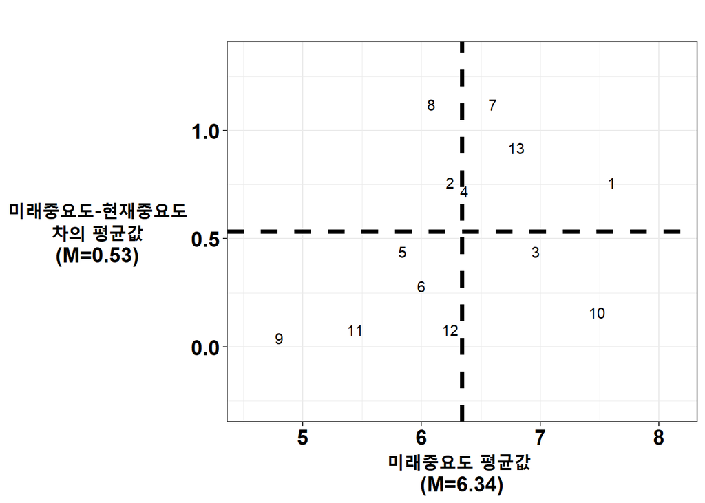

```r
## 가공1 ##
dfnd_L2_importance_L1 <- as.data.frame(t(dfnd_L2_importance))
rownames_imp <- rownames(dfnd_L2_importance_L1)
dfnd_L2_importance_L1 <- cbind(dfnd_L2_importance_L1,rownames_imp)
colnames(dfnd_L2_importance_L1) <- c("Importance","row_import")
## 가공1 ##

## 가공2 ##
dfnd_L2_gradient_L1 <- as.data.frame(t(dfnd_L2_gradient))
rownames_grad <- rownames(dfnd_L2_gradient_L1)
dfnd_L2_gradient_L1 <- cbind(dfnd_L2_gradient_L1,rownames_grad)
colnames(dfnd_L2_gradient_L1) <- c("Gradient","row_grad")
## 가공2 ##


## 최종 ##
result_set <- cbind(dfnd_L2_importance_L1,dfnd_L2_gradient_L1) %>%
  dplyr::mutate(data_label = paste0(seq(1:13)))

result_set_write <- result_set %>%
  dplyr::select(Importance,Gradient,data_label)

write.csv(result_set_write,"./dfnd",row.names = FALSE)

## ggplot ##
ggplot() +
  theme_bw() +
  theme(plot.title=element_text(face="bold", size=20, color="black")) +
  theme(axis.title.x = element_text(face="bold", size=15, colour="black")) +
  theme(axis.title.y = element_text(face="bold", size=15, colour="black", angle=0, vjust = 0.5)) +
  theme(axis.text.x = element_text(face="bold", size=15, colour="black")) +
  theme(axis.text.y = element_text(face="bold", size=15, colour="black")) +
  #labs(title = paste0("Locus For Focus Result (해외파병)")) +
  labs(title = paste0("")) +
  #geom_point(data=result_set, aes(x=val_import,y=val_grad),color = "black",size = 8) +
  #annotate("text", x = result_set$val_import, y = result_set$val_grad, label = "Some text") +
  geom_text(data = result_set, aes(x = Importance, y = Gradient, label = data_label)) +
  geom_hline(yintercept=total_mean_gradient,size = 1.5, linetype='dashed') +
  geom_vline(xintercept=total_mean_importance,size = 1.5, linetype='dashed') +
  xlim(total_mean_importance-1.8,total_mean_importance+1.8) +
  ylim(total_mean_gradient-0.8,total_mean_gradient+0.8) +
  xlab(paste0("미래중요도 평균값 \n", "(M=",round(total_mean_importance,2),")")) +
  ylab(paste0("미래중요도-현재중요도\n 차의 평균값 \n", "(M=",round(total_mean_gradient,2),")"))
```

```r
  #labs(title = paste0("WRF 300m ",daychr," night(04-05) mean WDIR and WS" ) ) +
```

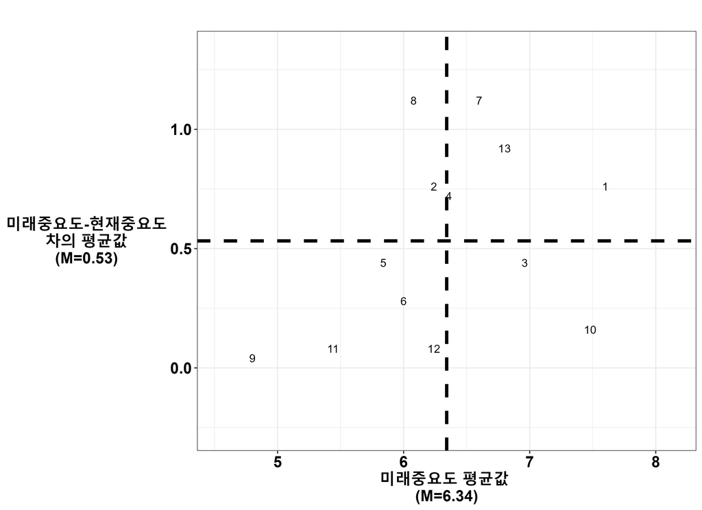

result

보내드리는 “rest_dfnd.png” 파일을 논문에 첨부하세요.

# 8. [표 5-14] AHP 분석과 요구분석 결과의 관계

==> 이는 위의 표를 정리하면 됩니다.